# Chess ELO Prediction with Neural Networks

**Goal:** Given a completed chess game, predict both players' Elo ratings from their playing style — not just the result.

The intuition is that *how* you play reveals your strength: strong players manage the clock more carefully, avoid blunders, and control territory more consistently than weaker players.

## Dataset

**Lichess open database, May 2017** — rated standard games. Each game is a PGN string with move annotations and optional clock times.

## Four architectures compared on the same data

| Model | Sequence processing |
| --- | --- |
| **BiLSTM** | Two-layer bidirectional LSTM with soft attention |
| **Residual MLP** | No sequences — pure engineered features |
| **1D CNN** | Three parallel conv branches (kernels 3, 5, 7) |
| **Transformer** | Multi-head self-attention encoder |

Each model predicts a **probability distribution** over 40 Elo bins (0–4000), trained with **KL divergence** against a Gaussian soft target.

```
PyTorch 2.5.1  |  CUDA: False
```

## Configuration

All experiment settings live here. Change `RUN_*` flags at the top to choose which models to train.

```
Device : cpu
Models : BiLSTM=True  Residual=True  CNN=True  Transformer=True
HPO    : BiLSTM=False  Residual=False  CNN=False  Transformer=False
```

## 1 · Data Loading

Lichess publishes monthly PGN dumps compressed with zstandard (`.zst`). We stream-parse the file game-by-game so we never decompress the entire file at once.

Each game becomes one row: header fields (White, Black, WhiteElo, BlackElo, TimeControl, …) plus a `Moves` column with the full annotated PGN move string.

```
Loaded 1,000,000 games  (38.1s)
After filters : 124,858 games
Elo range     : 775–2586
```

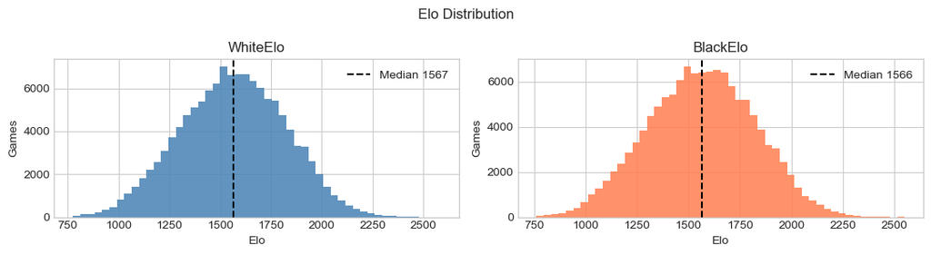

## 2 · Feature Engineering

We extract two groups of features that summarise a player's style without requiring real-time sequence processing at training time:

**Clock features** (~10 columns): Average, std, max time spent per move; time pressure in the last 5 moves; opening pace in the first 5 moves. All normalised by the base time-control.

Both are cached to disk after the first run.

```
Extracting board features (a few minutes)...
Done  (35 cols  80s) — cached
Extracting clock features...
Done  (10 cols  29s) — cached
```

```
Static features: 45
['acpl_black', 'acpl_white', 'b_avg_time_norm', 'b_max_time_norm', 'b_opening_pace', 'b_std_time_norm', 'b_time_pressure', 'black_territory_depth', 'blunder_count_black', 'blunder_count_white', 'blunder_density_black', 'blunder_density_white', 'capture_density', 'castle_move_black', 'castle_move_whi…
```

## 3 · Preprocessing

### Soft Elo targets

Rather than predicting a single number, we predict a **probability distribution** over 40 Elo bins. The target for a player with true rating *e* is a Gaussian with σ = 200 centred on *e*, normalised to sum to 1.

Training with **KL divergence** against this soft target naturally captures rating uncertainty — the model learns that 1400 and 1600 are close, not unrelated.

### Weighted sampling

Very low and very high Elo games are rare. **Inverse-frequency weighted sampling** oversamples these games during training so the model generalises across all skill levels.

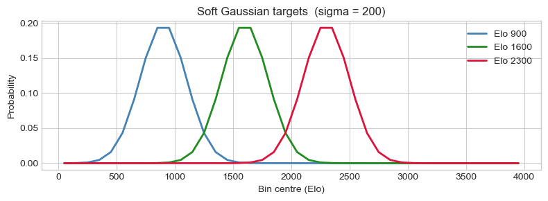

```
Train 99,886  val 12,486  test 12,486
Scaling applied (StandardScaler fit on train only)
```

```
Dropped 2,107 games shorter than 12 plies
Vocabulary: 7,644 distinct moves
```

```
Building datasets...
Built in 12s
Train batches per epoch: 768
```

## 4 · Model Architectures

### Development history

**v1–v2 — BiLSTM baseline (MAE ≈ 200)**  
Initial model: two-layer BiLSTM over move sequences plus hand-crafted static features (captures, checks, castling, clock usage). Early experiments used a strict time-control filter (10 min only) that left just ~23 k games — too few to generalise. Relaxing to ≥ 3 min and scaling to 200 k → 1 M games brought MAE to ~200 Elo.

**v3 — Soft targets + KL divergence (MAE ≈ 185)**  
Switching from Huber regression to KL divergence over Gaussian soft targets improved calibration and reduced MAE by ~15 Elo. Inspired by Ouzounis et al. (2022).

**v4 — Clock features + 1 M games (MAE ≈ 165)**  
Adding per-move clock statistics (time pressure, opening pace) and training on 1 M games closed the gap further. A sequence autoencoder (BiLSTM → 32-d bottleneck) was also tested to pre-compute sequence embeddings for faster CPU training.

**This notebook — Four architectures compared**  
All models use the same data, features, loss, and training loop for a fair comparison.

### Model 1 · BiLSTM with soft attention

A two-layer **bidirectional LSTM** reads the move sequence and produces a hidden state at each position. **Soft attention** learns to weight these states, allowing the model to focus on the most informative moves.

- *Strength*: captures long-range move dependencies and is sensitive to move order.
- *Weakness*: sequential computation cannot be parallelised; can lose signal from early moves in long games.

### Model 2 · Residual MLP (features only)

A deep **residual MLP** over the static feature vector — no move sequences.

Each residual block applies `LayerNorm → Linear → GELU → Dropout → Linear` and adds the result back via a skip connection. Pre-norm residual connections train stably at depth and avoid gradient vanishing.

- *Strength*: fastest to train, no sequence overhead, very interpretable.
- *Weakness*: cannot see *which moves* were played, only aggregate statistics.

### Model 3 · Multi-scale 1D CNN

**Three parallel Conv1d branches** with kernel sizes 3, 5, and 7 capture move patterns at different scales: short tactics (k=3), medium plans (k=5), and longer strategic ideas (k=7). After convolution, **global max-pooling** picks the strongest filter activation across the whole game.

### Model 4 · Transformer Encoder

**Multi-head self-attention** lets every move attend to every other move in O(1), unlike LSTM which passes information through a chain of sequential states.

We use **sinusoidal positional encodings** (fixed, not learned) and **pre-norm layers** (LayerNorm before the attention/FFN blocks) which train more stably at depth. After encoding, we **mean-pool** over non-padding positions.

- *Strength*: direct connections between any pair of moves; highly parallelisable on GPU.
- *Weakness*: quadratic memory in sequence length; advantage over LSTM is less clear on short sequences (most games are ≤ 60 moves).

## 5 · Training

All models share the same training loop:

- **Loss**: KL divergence between log-softmax predictions and the Gaussian soft targets
- **Optimiser**: AdamW with cosine annealing (LR decays to 5% of initial)
- **Gradient clipping** at norm 1.0
- **Early stopping**: restores best weights if validation MAE does not improve for `PATIENCE` consecutive epochs

## 5a · Hyperparameter Optimisation (optional)

When `HPO_*` is enabled for a model, [Optuna](https://optuna.org/) runs a quick search before the full training. Each trial trains on a small subset (`HPO_GAMES`) for a few epochs (`HPO_EPOCHS`) and evaluates on the validation set.

The best parameters are cached to `checkpoints/hpo_*.pkl` — re-running the cell is instant if the cache exists (delete the file to force a fresh search).

If HPO is disabled, the default values from the config cell are used.

**Searched parameters:**

- *BiLSTM*: hidden dim, dropout
- *Residual MLP*: hidden dim, number of residual blocks, dropout
- *CNN*: filters per branch, embedding dim, dropout
- *Transformer*: d_model, attention heads, encoder layers, feedforward dim, dropout

```
HPO disabled — using default hyperparameters from config

Final params:
  BiLSTM      : {'hidden': 128, 'dropout': 0.3}
  Residual MLP: {'hidden': 256, 'n_blocks': 4, 'dropout': 0.3}
  CNN         : {'n_filters': 64, 'embed_dim': 64, 'dropout': 0.3}
  Transformer : {'d_model': 128, 'n_heads': 4, 'n_layers': 2, 'ff_dim': 256, 'dropout': 0.3}
```

```
Training BiLSTM
----------------------------------------
   1/10  loss=1.2375  val_mae=190.4
   2/10  loss=0.8050  val_mae=175.8
   3/10  loss=0.7033  val_mae=173.8
   4/10  loss=0.6368  val_mae=162.6
   5/10  loss=0.5925  val_mae=170.1
   6/10  loss=0.5602  val_mae=162.4
   7/10  loss=0.5339  val_mae=158.2
   8/10  loss=0.5221  val_mae=159.9
   9/10  loss=0.5085  val_mae=159.7
  10/10  loss=0.5022  val_mae=158.5
  Early stop at epoch 10
  Test MAE: 158.7

Training Residual MLP
----------------------------------------
   1/10  loss=1.1433  val_mae=214.6
   2/10  loss=0.9422  val_mae=214.5
   3/10  loss=0.8872  val_mae=192.7
   4/10  loss=0.8448  val_mae=208.1
   5/10  loss=0.8173  val_mae=196.5
   6/10  loss=0.7928  val_mae=190.0
   7/10  loss=0.7745  val_mae=193.3
   8/10  loss=0.7596  val_mae=193.4
   9/10  loss=0.7467  val_mae=193.3
  Early stop at epoch 9
  Test MAE: 190.1

Training CNN
----------------------------------------
   1/10  loss=1.0386  val_mae=176.0
   2/10  loss=0.6190  val_mae=171.1
   3/10  loss=0.5214  val_mae=176.6
   4/10  loss=0.4692  val_mae=168.8
   5/10  loss=0.4289  val_mae=172.4
   6/10  loss=0.4008  val_mae=176.7
   7/10  loss=0.3749  val_mae=173.9
  Early stop at epoch 7
  Test MAE: 169.2

Training Transformer
----------------------------------------
   1/10  loss=1.1519  val_mae=169.6
   2/10  loss=0.8165  val_mae=172.0
   3/10  loss=0.7309  val_mae=175.0
   4/10  loss=0.6705  val_mae=175.7
  Early stop at epoch 4
  Test MAE: 169.3
```

## 6 · Results & Comparison

```
             White MAE Black MAE Combined MAE Within 100 Within 200 Within 300
Model
BiLSTM           159.1     158.2        158.7      26.2%      58.7%      80.8%
Residual MLP     190.4     189.8        190.1      20.6%      50.0%      72.5%
CNN              170.2     168.3        169.2      24.2%      55.4%      77.8%
Transformer      169.0     169.6        169.3      24.1%      55.9%      77.7%
```

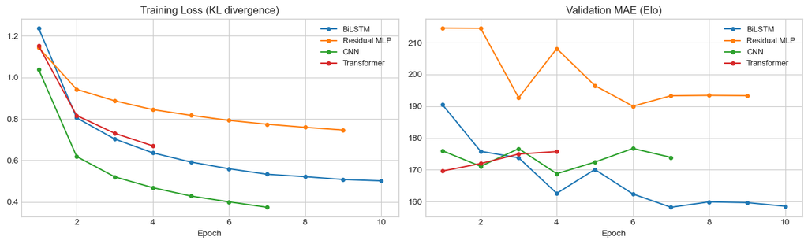

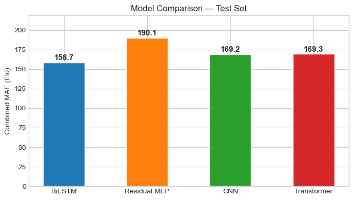

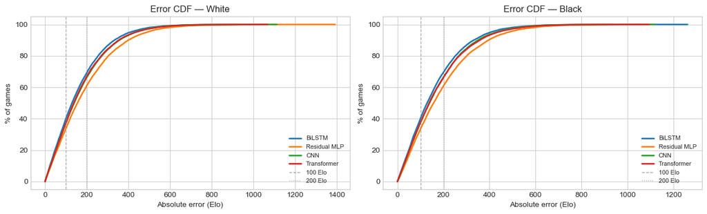

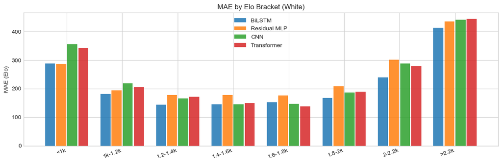

## 7 · Ensemble

When multiple models are trained, we average their **predicted distributions** (not just the point estimates). Because each model's errors are partially independent, ensemble averaging typically improves both accuracy and calibration.

```
Ensemble combined MAE: 153.6  (White 153.8, Black 153.4)
```

```
==================================================
             Combined MAE Within 100 Within 200 Within 300
Model
BiLSTM              158.7      26.2%      58.7%      80.8%
Residual MLP        190.1      20.6%      50.0%      72.5%
CNN                 169.2      24.2%      55.4%      77.8%
Transformer         169.3      24.1%      55.9%      77.7%
Ensemble            153.6      26.3%      60.4%      82.0%
==================================================
Best single model: BiLSTM  (MAE = 158.7)
```

## 8 · Single Game Demo

Paste any PGN string below and run the cell to predict both players' Elo ratings using every trained model.

```
Model                White Elo   Black Elo
--------------------------------------------
  BiLSTM                  1710        1693
  Residual MLP            1809        1756
  CNN                     1773        1765
  Transformer             1764        1755
```